# Stock Price Time Series Analysis

Derek Tang

4/26/2020

## Executive Summary

In this report, we analyze and model a dataset consisting of stock prices across 4 years of trading days in order to predict prices for the first ten trading days in October 2019. The model we settle on is an ARMA(1, 1, 0) model with one autoregressive parameter aftern differencing. Ultimately, we find that our stock price is modelled quite well as a random walk along with a linear trend. Our forecasted values therefore are very close to a linear extrapolation of the trend line.

## Exploratory Data Analysis

Before we begin modelling, we must first investigate our dataset and see if we can take any preprocessing steps. Plotting the original time series, we immediately notice that there is clear downward trend which looks quite linear at first glance. Additionally, we can see that the variance is heteroskedastic, with higher variances appearing at higher stock prices, which makes sense because price movements are typically analyzed as percent changes rather than absolute movement. The relationship between variance and mean lead me to pursue a log transformation to stabilize the variance.

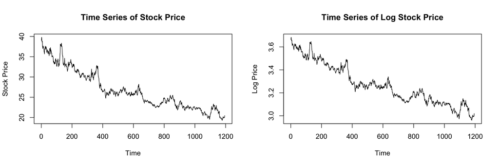

Left: Time series plot of stock price data. Right: Time series plot of log transformed stock price data

We can see here that the variance now looks much more homoskedastic after the log transformation. Given that we are dealing with stock prices, one might guess that more dramatic price movements can be correlated to earnings reports, which come out at quarterly intervals, or perhaps other outside events (i.e. elections, Trump tweets, etc). Also, we notice that not all days have price data - weekends and holidays are excluded from the US trading calendar. This is something to note as it can create imperfect periods if we are looking to model seasonality in the data.

## Models Considered

After considering the nature of stock price movements and the data itself, it was clear that in order to achieve stationarity I would have to remove the trend - I chose to do this by differencing the data. Additionally, in order to address possible seasonality within the data, I created a new dataset that filled in missing data on holidays with the average of the preceding and following trading days data points such that we can clearly define a “trading week” as five data points. I decided to model both this new dataset as well as the original dataset.

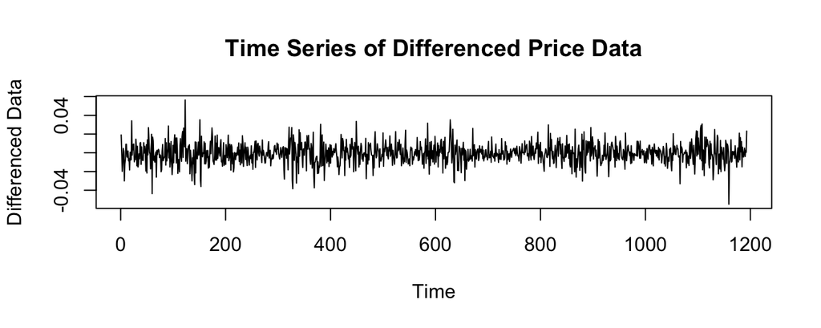

Time series plot of our differenced data

### Model 1: Original Dataset

Our differenced data looks quite stable, so the next thing I did was to look at the sample acf and pacf plots across a large amount of lags to check for stationarity.

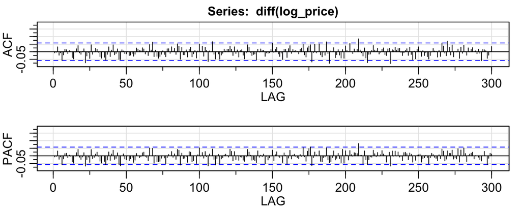

Sample ACF and PACF plot for our differenced data.

Based on these plots, it is hard to see a discernable pattern that would influence me towards picking a particular p or q for ARMA analysis and in fact the time series looks pretty close to stationary with only a few autocorrelations exceeding our 95% confidence interval which lead me to believe that this process could be modelled by few parameters. As no periodic pattern appears evident, I decided to use auto.arima() to help in parameter selection, and it chose an ARMA(1, 1, 0) model to fit the data.

In fact, when we use sarima() to fit the parameters of the model, we end up with a very small ar(1) coefficient which tells us that our data essentially resembles a random walk! This result is not too surprising in the context of our stock price, since we removed a linear trend with differencing leaving us with a process that is very close to stationary. I examined the plots from R’s sarima() function on our chosen model, and saw encouraging results. The acf of the residuals looks to be well contained in our confidence intervals, and the Ljung-Box test gives us no indication to reject our model as none of the p-values fall below the significance level.

### Model 2: Cleaned Data

We now move to our new dataset, with substituted values. The goal of the substitution is to see if we can observe any clear seasonality on a monthly or quarterly basis.

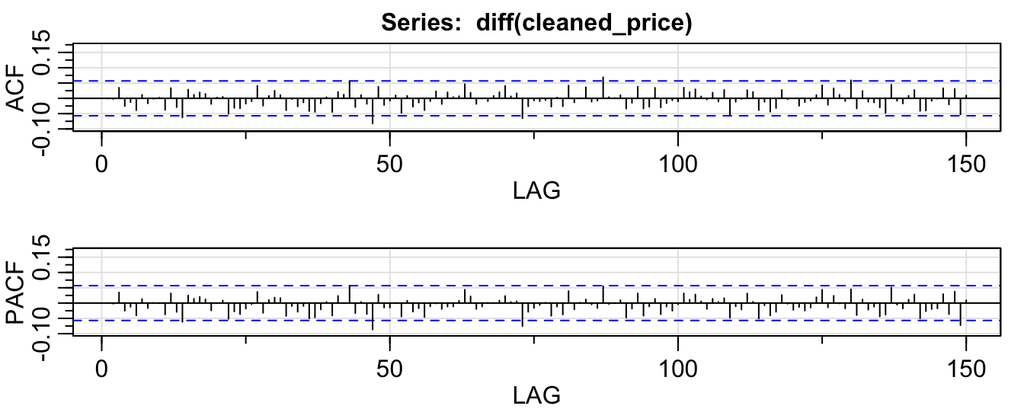

Sample ACF and PACF plot for our differenced data.

However, after scrutinizing the acf and pacf plots, no discernable pattern appears, and for the most part the autocorrelations stay within the blue bands, however there are certainly a few outliers. Again, we turn to R’s auto.arima() function, which proposes the model ARMA(3, 1, 4) for the new data set. We will let this be our model on the new “cleaned” data set. After analyzing the outplut plots from fitting the data with sarima(), I concluded that the our model is quite reasonable, as the ACF of the residuals looks stationary and the Ljung-Box test does not have any points that would lead us to reject our model.

## Model Comparison and Selection:

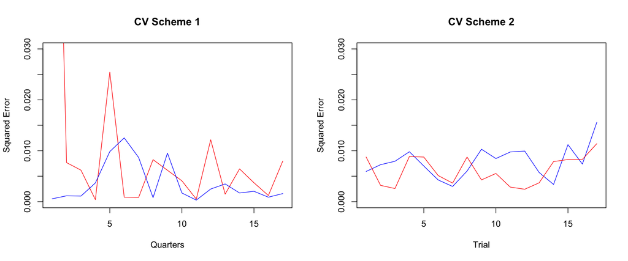

## Results

I have selected the ARMA(1, 1, 0) model to generate predictions for the next 10 trading days, using the entirety of the original data set. From our sarima() function, we retrieve the estimate for our autoregressive parameter as well as our drift parameter (the slope for our trend):

|  | Estimate | Standard Error |
| --- | --- | --- |
| ar1 | -0.0070195 | 0.0290316 |
| constant | -0.0005406 | 0.0003233 |

We see that the autoregressive parameter is really very small, and with a confidence interval that includes 0. Below, we can see the predictions for the next ten trading days that our model produces as well as the error margins of the estimates.

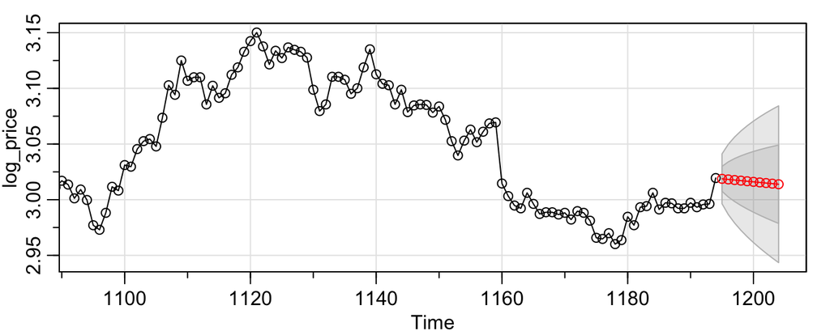

Of course, to retrive our actual predictions, we must reverse the log transformation.